# Week12

## Create indicator variables

For all values replaced with NAs or other abnormalities noted above, we will create indicator variables in case there is systematic missingness.

```r
hosp <- hosp %>%
  mutate(redacted = ifelse(is.na(hosp$Area), 1, 0),
         na.zip = ifelse(is.na(Zip), 1, 0),
         invalid.drg = ifelse(is.na(DRG.Code), 1, 0),
         na.payment1 = ifelse(Payment1=="Unknown", 1, 0),
         no.payment2 = ifelse(is.na(Payment2), 1, 0),
         unknown.payment2 = ifelse(Payment2=="Unknown", 1, 0),
         no.payment3 = ifelse(is.na(Payment3), 1, 0),
         unknown.payment3 = ifelse(Payment3 == "Unknown", 1, 0),
         if.birth = ifelse(is.na(Birthweight), 0, 1),
         na.gender = ifelse(is.na(Gender), 1, 0),
         na.ethnicity = ifelse(is.na(Ethnicity), 1, 0),
         na.surgical = ifelse(is.na(Surgical), 1, 0),
         high.id = ifelse(Facility.ID > 9000, 1, 0),
         na.type = ifelse(is.na(Type), 1, 0),
         na.discharge = ifelse(is.na(Discharge.Status), 1, 0),
         na.ccs = ifelse(is.na(CCS.Code), 1, 0),
         na.ccs.procedure = ifelse(is.na(CCS.Procedure.Code), 1, 0),
         na.mdc = ifelse(is.na(MDC.Code), 1, 0)
         )
```

## Feature Engineering

Besides the feature already made (chargeratio), we added the following features. First, the median family income of the first 3 digits of the various patient zip codes, which we thought would serve as a marker of patient wealth (and thus health). Second, the number of payment types, which we also thought could indicate patient age or financial standing. Third, we grouped the CCS procedures by area of the body to decrease its number of levels, so it could be used as a categorical variable. Fourth, we found the median income for the county that each hospital was located in, which we thought would indicate hospital funding/quality.

```r
# median income for the diff zipcodes
# read in income file
rakib2 <- "C:\\Users\\Rakib Kamal\\Documents\\GitHub\\FinalProject\\zipcodes - Sheet1.csv"
ashley2 <- "C:/Users/Ashley Hirt/Documents/GitHub/FinalProject/zipcodes - Sheet1.csv"
incomes <- read.csv(file=ashley2)
colnames(incomes)[1] <- "Zip" # rename zip.code column
# perform left outer join on our hosp dataset and the income dataset, by Zipcode
hosp <- merge(hosp, incomes, by="Zip", all=T)
# rename the median income column
colnames(hosp)[which(colnames(hosp)=="Median.Income..family.")] <- "Median.Income"


# number of payment types
hosp <- hosp %>%
  mutate(numpay = case_when(
    is.na(Payment2) & is.na(Payment3) ~ 1,
    !is.na(Payment2) & is.na(Payment3) ~ 2,
    !is.na(Payment2) & !is.na(Payment3) ~ 3
  ))

# self-pay indicator
hosp <- hosp %>%
  mutate(selfpay = case_when(
    Payment1 == "Self-Pay" ~ 1,
    Payment2 == "Self-Pay" ~ 1,
    Payment3 == "self-Pay" ~ 1,
    TRUE ~ 0
  ))

# overall grouping for each CCS procedure (see works cited, reference 1)
hosp <- hosp %>%
  mutate(CCS.Procedure.Group = case_when(
    CCS.Procedure.Code %in% c(1:9, 199, 188) ~ "Nervous System",
    CCS.Procedure.Code %in% c(10:12) ~ "Endocrine System",
    CCS.Procedure.Code %in% c(13:21, 220) ~ "Eyes",
    CCS.Procedure.Code %in% c(22:33) ~ "ENT",
    CCS.Procedure.Code %in% c(34:42, 216:217, 208) ~ "Respiratory System",
    CCS.Procedure.Code %in% c(43:63, 201:203, 205, 225, 189:191, 193, 204) ~ "Cardiovascular System",
    CCS.Procedure.Code %in% c(64:67, 222, 228) ~ "Hemic and Lymphatic System",
    CCS.Procedure.Code %in% c(69:99, 194, 223, 184:186, 221) ~ "Digestive System",
    CCS.Procedure.Code %in% c(100:112, 195, 187, 200) ~ "Urinary System",
    CCS.Procedure.Code %in% c(113:118) ~ "Male Genital Organs",
    CCS.Procedure.Code %in% c(119:123) ~ "Female Genital Organs",
    CCS.Procedure.Code %in% c(124:141) ~ "Obstetrical Procedures",
    CCS.Procedure.Code %in% c(142:164, 207, 212:215, 230) ~ "Musculoskeletal",
    CCS.Procedure.Code %in% c(165:175, 182) ~ "Integumentary System and Breast",
    CCS.Procedure.Code %in% c(176:181, 192, 183, 219, 218, 197, 198, 209, 210, 196, 211, 226, 227, 229, 231, 224) ~ "Misc or Diagnostic",
    CCS.Procedure.Code == 0 ~ "Ungroupable",
    is.na(CCS.Procedure.Code) ~ "No Procedure"
  ))


# median income for each county (used to extrapolate hospital tax funds in the area)
# read in county data
rakib3 <- "C:\\Users\\Rakib Kamal\\Documents\\GitHub\\FinalProject\\county.csv"
ashley3 <- "C:/Users/Ashley Hirt/Documents/GitHub/FinalProject/county.csv"
county <- read.csv(ashley3)
# left outer join with county data
hosp <- merge(hosp, county, by="County", all=T)
```

Finally, we created a grouping for DRG, which originally had over 300 levels. This grouping was made by manually examining boxplots of each DRG code and grouping codes according to their medical similarity and the similarity of their charge distributions. This would (hopefully) assist in model building later. The boxplots showing charge distributions for DRG codes that were grouped are shown in the appendix; only the feature engineering code is shown here.

```r
# create DRG vars based off boxplots shown in appendix graphs
hosp <- hosp %>%
  mutate(drg.group = case_when(
    DRG.Code<4 | DRG.Code==6 | DRG.Code==440 ~ "Transplant",
    DRG.Code < 40 & DRG.Code >=20 ~ "Nervous System Procedures",
    DRG.Code == 49 | DRG.Code == 50 ~ "Nervous System Infection (excl. meningitis)",
    DRG.Code >= 89 & DRG.Code <= 93 ~ "Head/Neck Procedures",
    DRG.Code >= 120 & DRG.Code <= 130 ~ "Respiratory Procedures",
    DRG.Code <= 223 & DRG.Code >= 220 ~ "Stomach/Bowel Procedures (excl. hernia)",
    DRG.Code == 229 ~ "Stomach/Bowel Procedures (excl. hernia)",
    DRG.Code <= 264 & DRG.Code >= 260 ~ "Liver/Abdominal Procedures",
    DRG.Code %in% c(301, 302, 308, 309) ~ "Hip/Knee/Femur Surgery",
    DRG.Code %in% c(303, 304, 321) ~ "Spinal Fusion",
    DRG.Code %in% c(362, 363) ~ "Breast Procedures",
    DRG.Code <= 447 & DRG.Code >= 441 ~ "Kidney/Urinary Procedures",
    DRG.Code <=566 & DRG.Code >= 540 ~ "Obstetric Procedures/Diagnoses",
    DRG.Code %in% c(650, 651) ~ "Spleen/Blood Procedures",
    DRG.Code <=692 & DRG.Code >= 690 ~ "Leukemia/Radiotherapy",
    DRG.Code <=711 & DRG.Code >= 710 ~ "Infection w/ OR Procedure",
    (DRG.Code <=776 & DRG.Code >= 773) | DRG.Code == 770 ~ "Alcohol/Drug Abuse w/o Rehab",
    DRG.Code <=842 & DRG.Code >= 841 ~ "Burns with Skin Graft",
    DRG.Code %in% c(850, 860, 862, 863) ~ "Rehab/Aftercare",
    DRG.Code <=912 & DRG.Code >= 910 ~ "Multiple Significant Trauma with Procedure",
    TRUE ~ "Other"
  ))
```

## Appendix

Below is the code and graphs used to create the DRG groupings discussed earlier. The median charge is indicated as a dark blue dashed line. Outliers were removed and the y axis was scaled to provide appropriate resolution of the boxplots.

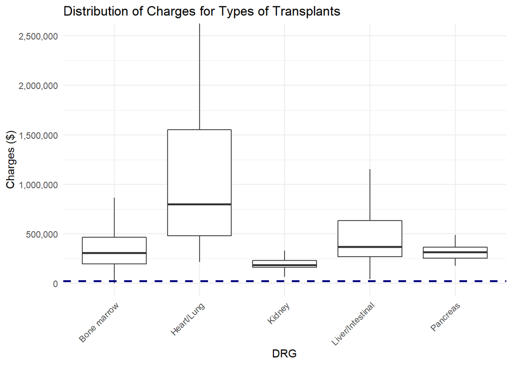

```r
# graph transplant vs. charges
ggplot(filter(hosp, DRG.Code < 4 | DRG.Code==440 | DRG.Code==6),
       aes(x=DRG, y=Charges)) +
  geom_boxplot(outlier.shape=NA) +
  geom_hline(yintercept=median(hosp$Charges), linetype="dashed", size=1, color="navy blue") +
  coord_cartesian(ylim=c(0,2500000)) +
  scale_y_continuous(labels=scales::comma) +
  theme(axis.text.x = element_text(angle=45, vjust=1, hjust=1)) +
  scale_x_discrete(labels=c("Bone marrow", "Heart/Lung",
                            "Kidney", "Liver/Intestinal",
                            "Pancreas")) +
  ggtitle("Distribution of Charges for Types of Transplants") +
  xlab("DRG") +
  ylab("Charges ($)")
```

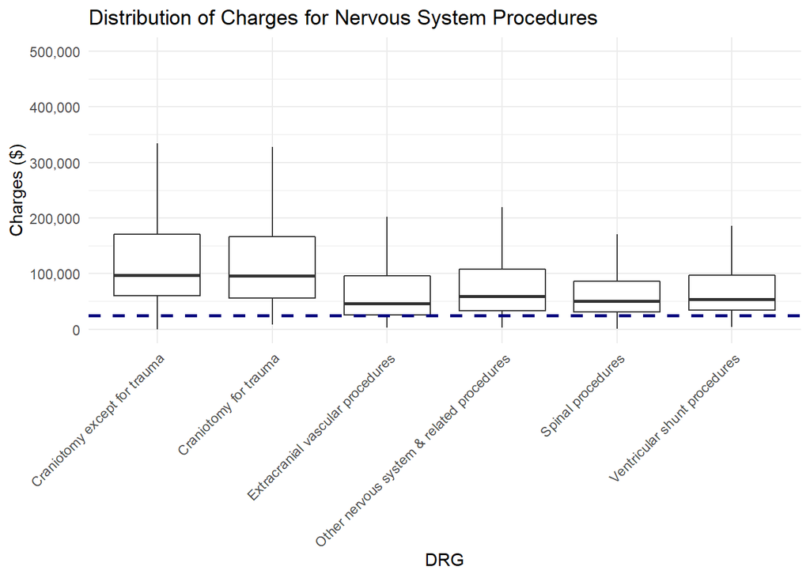

```r
# graph nervous system procedures vs. charges
ggplot(filter(hosp, DRG.Code <40 & DRG.Code >= 20),
       aes(x=DRG, y=Charges)) +
  geom_boxplot(outlier.shape=NA) +
  geom_hline(yintercept=median(hosp$Charges), linetype="dashed", size=1, color="navy blue") +
  coord_cartesian(ylim=c(0,500000)) +
  scale_y_continuous(labels=scales::comma) +
  theme(axis.text.x = element_text(angle=45, vjust=1, hjust=1)) +
  ggtitle("Distribution of Charges for Nervous System Procedures") +
  xlab("DRG") +
  ylab("Charges ($)")
```

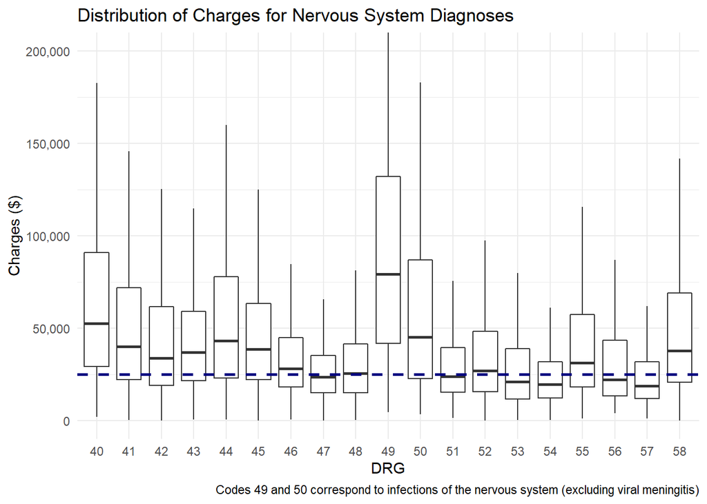

```r
# graph nervous system diagnoses vs. charges
ggplot(filter(hosp, DRG.Code <60 & DRG.Code >= 40),
       aes(x=as.factor(DRG.Code), y=Charges)) +
  geom_boxplot(outlier.shape=NA) +
  geom_hline(yintercept=median(hosp$Charges), linetype="dashed", size=1, color="navy blue") +
  coord_cartesian(ylim=c(0,200000)) +
  scale_y_continuous(labels=scales::comma) +
  ggtitle("Distribution of Charges for Nervous System Diagnoses") +
  xlab("DRG") +
  ylab("Charges ($)") +
  labs(caption="Codes 49 and 50 correspond to infections of the nervous system (excluding viral meningitis)")
```

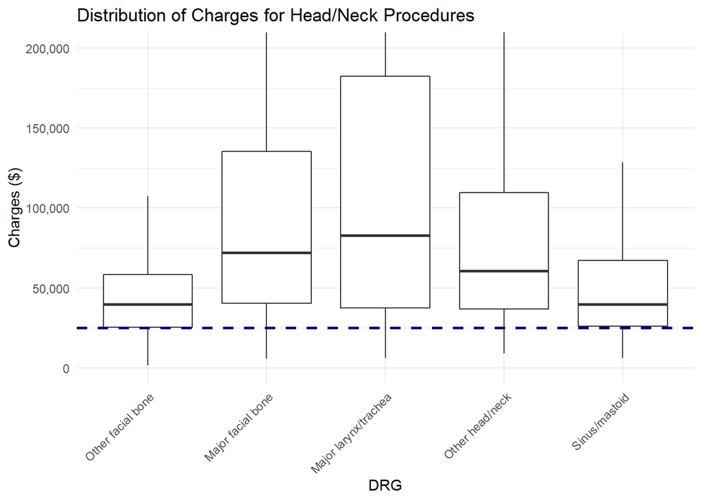

```r
# graph head/neck procedures vs charges
ggplot(filter(hosp, DRG.Code <=93 & DRG.Code >= 89),
       aes(x=DRG, y=Charges)) +
  geom_boxplot(outlier.shape=NA) +
  geom_hline(yintercept=median(hosp$Charges), linetype="dashed", size=1, color="navy blue") +
  coord_cartesian(ylim=c(0,200000)) +
  scale_y_continuous(labels=scales::comma) +
  theme(axis.text.x=element_text(angle=45, hjust=1, vjust=1)) +
  scale_x_discrete(labels=c("Other facial bone", "Major facial bone",
                            "Major larynx/trachea", "Other head/neck",
                            "Sinus/mastoid")) +
  ggtitle("Distribution of Charges for Head/Neck Procedures") +
  xlab("DRG") +
  ylab("Charges ($)")
```

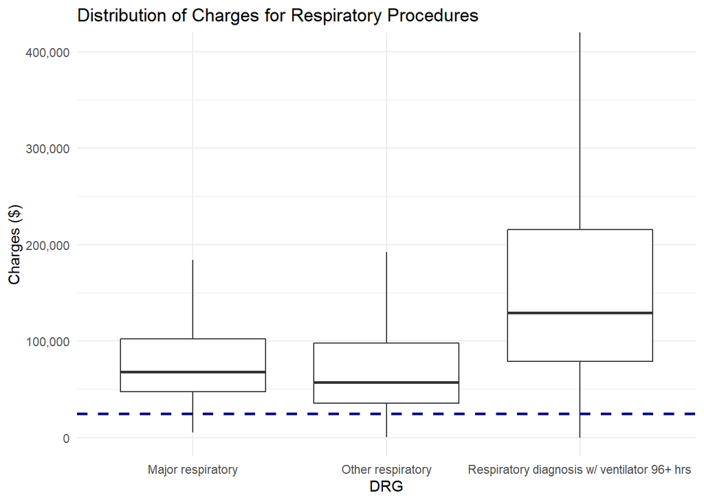

```r
# graph respiratory procedures vs. charges
ggplot(filter(hosp, DRG.Code <=130 & DRG.Code >= 120),
       aes(x=DRG, y=Charges)) +
  geom_boxplot(outlier.shape=NA) +
  geom_hline(yintercept=median(hosp$Charges), linetype="dashed", size=1, color="navy blue") +
  coord_cartesian(ylim=c(0,400000)) +
  scale_y_continuous(labels=scales::comma) +
  scale_x_discrete(labels=c("Major respiratory", "Other respiratory", "Respiratory diagnosis w/ ventilator 96+ hrs")) +
  ggtitle("Distribution of Charges for Respiratory Procedures") +
  xlab("DRG") +
  ylab("Charges ($)")
```

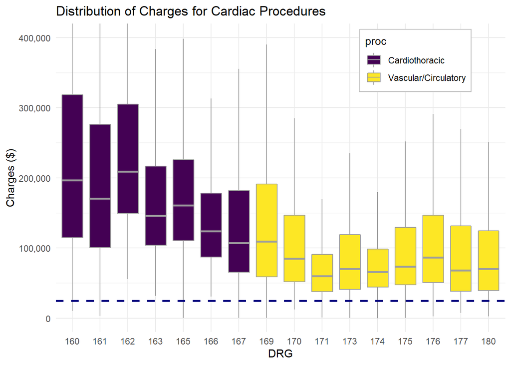

```r
# create indicator var for cardiothoracic vs. vascular/circulatory procedures (purely for graphing)
hosp_temp <- hosp %>%
  filter(DRG.Code <= 180 & DRG.Code >= 160) %>%
  mutate(
    proc = case_when(
      DRG.Code <= 167 ~ "Cardiothoracic",
      DRG.Code > 167 ~ "Vascular/Circulatory"
    )
  )
# graph cardiac procedures vs. charges
ggplot(hosp_temp, aes(x=as.factor(DRG.Code), y=Charges, fill=proc)) +
  geom_boxplot(outlier.shape=NA, color="grey62") +
  geom_hline(yintercept=median(hosp$Charges), linetype="dashed", size=1, color="navy blue") +
  coord_cartesian(ylim=c(0,400000)) +
  scale_y_continuous(labels=scales::comma) +
  scale_fill_viridis_d() +
  ggtitle("Distribution of Charges for Cardiac Procedures") +
  xlab("DRG") +
  ylab("Charges ($)") +
  theme(legend.position=c(.8,.88),
        legend.background=element_rect(fill="white", color="grey"),
        legend.title=element_text("Type of Cardiac Procedure"))
```

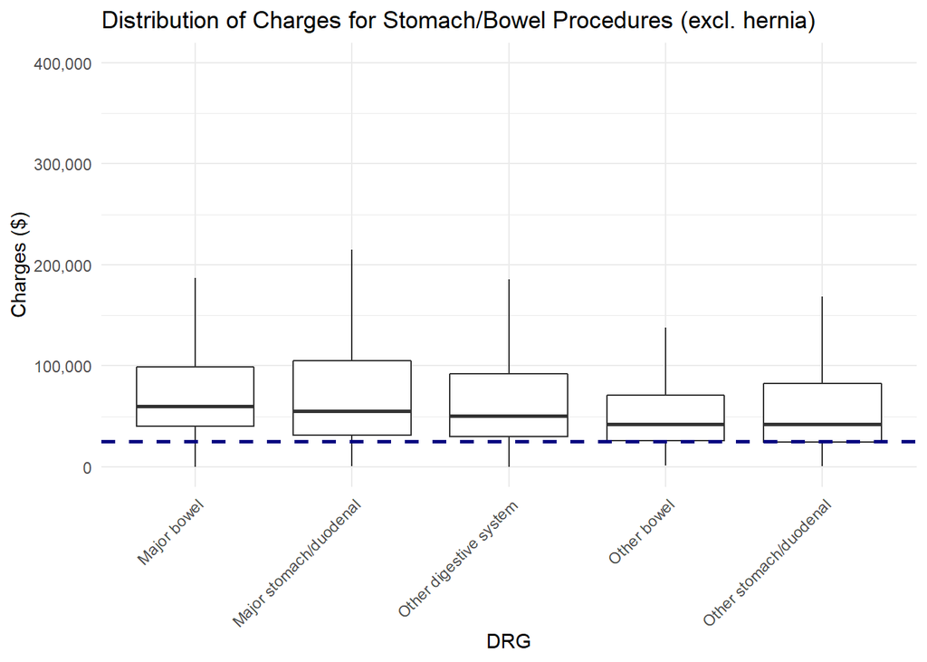

```r
# graph stomach/bowel procedures vs. charges
ggplot(filter(hosp, (DRG.Code <=223 & DRG.Code >= 220) | DRG.Code==229),
       aes(x=DRG, y=Charges)) +
  geom_boxplot(outlier.shape=NA) +
  geom_hline(yintercept=median(hosp$Charges), linetype="dashed", size=1, color="navy blue") +
  coord_cartesian(ylim=c(0,400000)) +
  scale_y_continuous(labels=scales::comma) +
  theme(axis.text.x=element_text(angle=45, vjust=1, hjust=1)) +
  scale_x_discrete(labels=c("Major bowel", "Major stomach/duodenal",
                            "Other digestive system", "Other bowel", "Other stomach/duodenal")) +
  ggtitle("Distribution of Charges for Stomach/Bowel Procedures (excl. hernia)") +
  xlab("DRG") +
  ylab("Charges ($)")
```

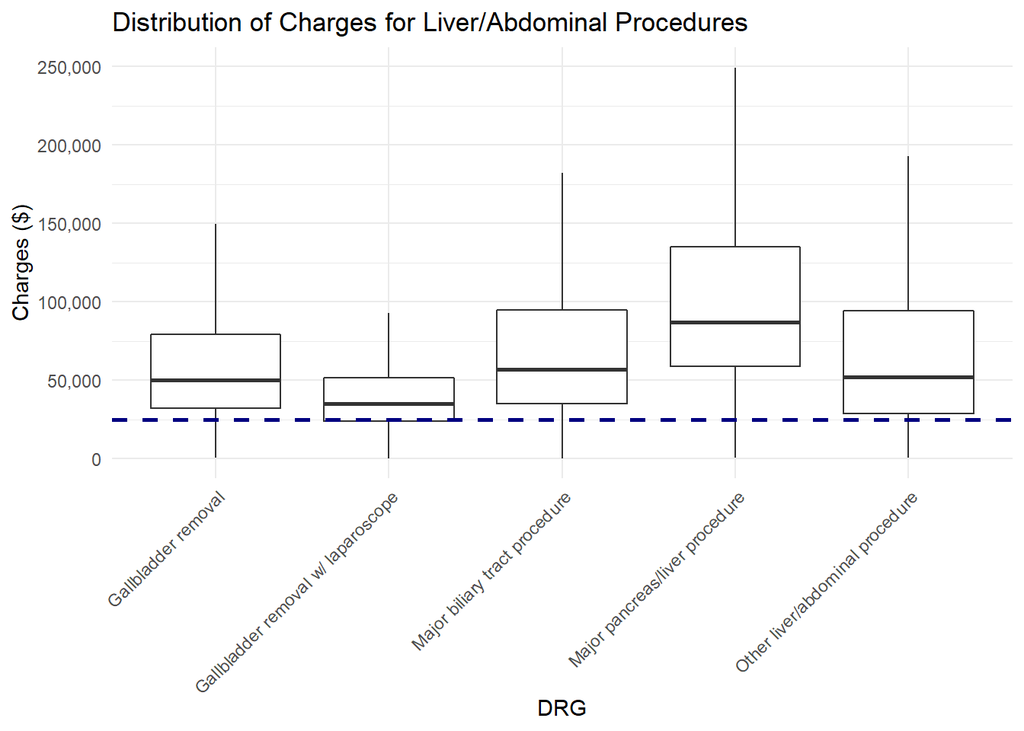

```r
# graph liver/abdominal procedures vs. charges
ggplot(filter(hosp, (DRG.Code <=264 & DRG.Code >= 260)),
       aes(x=DRG, y=Charges)) +
  geom_boxplot(outlier.shape=NA) +
  geom_hline(yintercept=median(hosp$Charges), linetype="dashed", size=1, color="navy blue") +
  coord_cartesian(ylim=c(0,250000)) +
  theme(axis.text.x=element_text(angle=45, hjust=1, vjust=1)) +
  scale_x_discrete(labels=c("Gallbladder removal", "Gallbladder removal w/ laparoscope",
                            "Major biliary tract procedure", "Major pancreas/liver procedure",
                            "Other liver/abdominal procedure")) +
  scale_y_continuous(labels=scales::comma) +
  ggtitle("Distribution of Charges for Liver/Abdominal Procedures") +
  xlab("DRG") +
  ylab("Charges ($)")
```

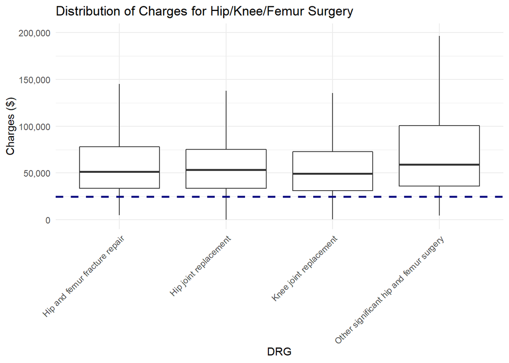

```r
# graph hip/knee/femur surgery vs. charges
ggplot(filter(hosp, DRG.Code %in% c(301, 302, 308, 309)),
       aes(x=DRG, y=Charges)) +
  geom_boxplot(outlier.shape=NA) +
  geom_hline(yintercept=median(hosp$Charges), linetype="dashed", size=1, color="navy blue") +
  coord_cartesian(ylim=c(0,200000)) +
  theme(axis.text.x=element_text(angle=45, hjust=1, vjust=1)) +
  scale_y_continuous(labels=scales::comma) +
  ggtitle("Distribution of Charges for Hip/Knee/Femur Surgery") +
  xlab("DRG") +
  ylab("Charges ($)")
```

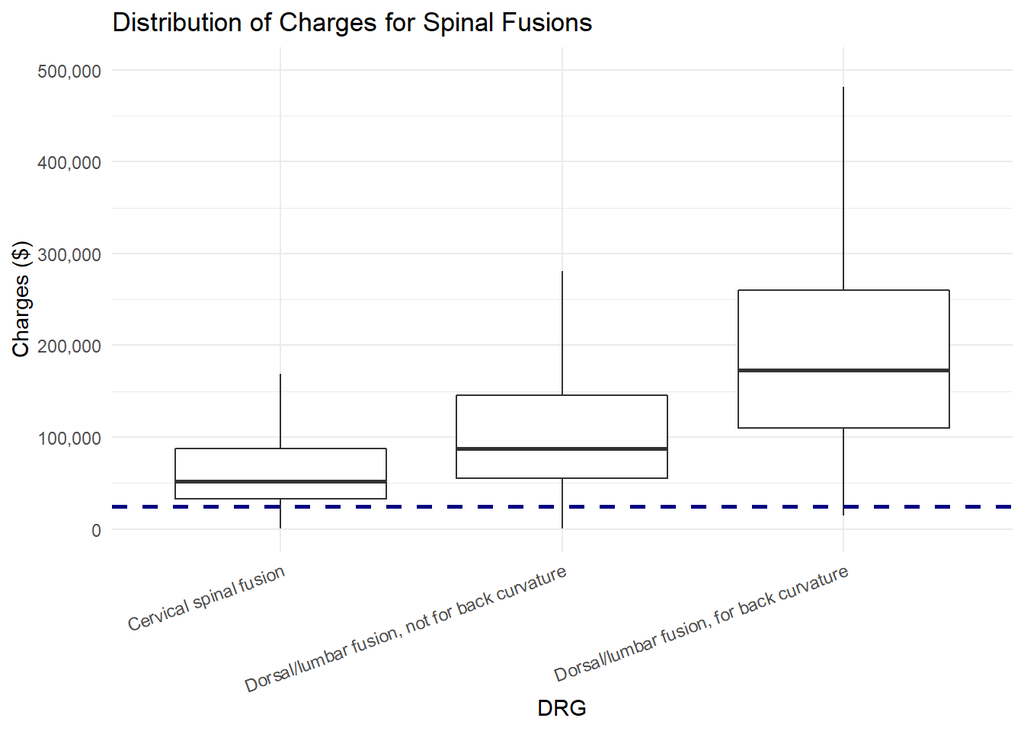

```r
# graph spinal fusions vs. charges
ggplot(filter(hosp, DRG.Code %in% c(303, 304, 321)),
       aes(x=DRG, y=Charges)) +
  geom_boxplot(outlier.shape=NA) +
  geom_hline(yintercept=median(hosp$Charges), linetype="dashed", size=1, color="navy blue") +
  coord_cartesian(ylim=c(0,500000)) +
  scale_x_discrete(labels=c("Cervical spinal fusion",
                            "Dorsal/lumbar fusion, not for back curvature",
                            "Dorsal/lumbar fusion, for back curvature")) +
  theme(axis.text.x=element_text(angle=20, hjust=1, vjust=1)) +
  scale_y_continuous(labels=scales::comma) +
  ggtitle("Distribution of Charges for Spinal Fusions") +
  xlab("DRG") +
  ylab("Charges ($)")
```

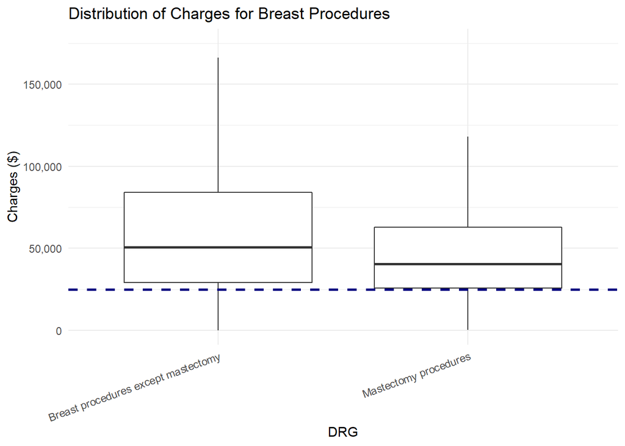

```r
# graph breast procedures vs. charges
ggplot(filter(hosp, (DRG.Code <=363 & DRG.Code >= 362)),
       aes(x=DRG, y=Charges)) +
  geom_boxplot(outlier.shape=NA) +
  geom_hline(yintercept=median(hosp$Charges), linetype="dashed", size=1, color="navy blue") +
  coord_cartesian(ylim=c(0,175000)) +
  theme(axis.text.x=element_text(angle=20, hjust=1, vjust=1)) +
  scale_y_continuous(labels=scales::comma) +
  ggtitle("Distribution of Charges for Breast Procedures") +
  xlab("DRG") +
  ylab("Charges ($)")
```

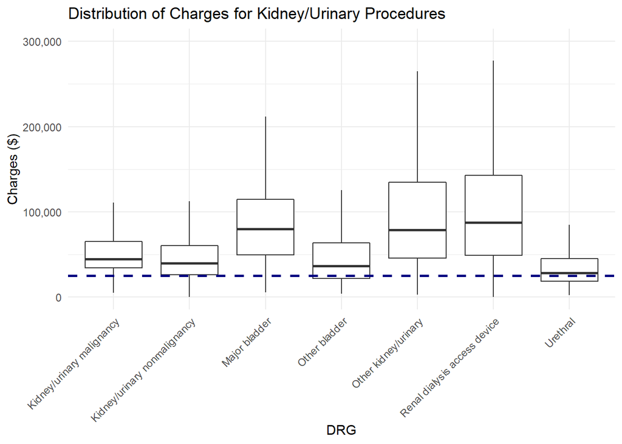

```r
# graph kidney/urinary procedures vs. charges
ggplot(filter(hosp, (DRG.Code <=447 & DRG.Code >= 441)),
       aes(x=DRG, y=Charges)) +
  geom_boxplot(outlier.shape=NA) +
  geom_hline(yintercept=median(hosp$Charges), linetype="dashed", size=1, color="navy blue") +
  coord_cartesian(ylim=c(0,300000)) +
  scale_y_continuous(labels=scales::comma) +
  theme(axis.text.x=element_text(angle=45, hjust=1, vjust=1)) +
  scale_x_discrete(labels=c("Kidney/urinary malignancy",
                            "Kidney/urinary nonmalignancy",
                            "Major bladder",
                            "Other bladder",
                            "Other kidney/urinary",
                            "Renal dialysis access device",
                            "Urethral")) +
  ggtitle("Distribution of Charges for Kidney/Urinary Procedures") +
  xlab("DRG") +
  ylab("Charges ($)")
```

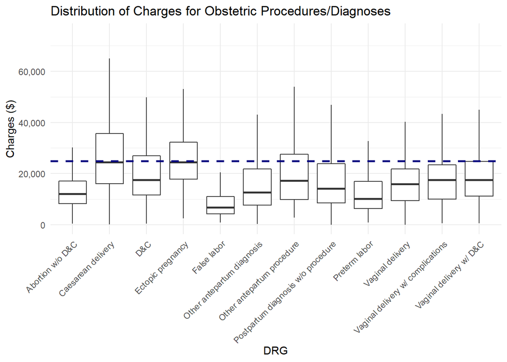

```r
# graph ostetric procedures/diagnoses vs. charges
ggplot(filter(hosp, (DRG.Code <=566 & DRG.Code >= 540)),
       aes(x=DRG, y=Charges)) +
  geom_boxplot(outlier.shape=NA) +
  geom_hline(yintercept=median(hosp$Charges), linetype="dashed", size=1, color="navy blue") +
  coord_cartesian(ylim=c(0,75000)) +
  theme(axis.text.x=element_text(angle=45, hjust=1, vjust=1)) +
  scale_y_continuous(labels=scales::comma) +
  scale_x_discrete(labels=c("Abortion w/o D&C",
                            "Caesarean delivery",
                            "D&C",
                            "Ectopic pregnancy",
                            "False labor",
                            "Other antepartum diagnosis",
                            "Other antepartum procedure",
                            "Postpartum diagnosis w/o procedure",
                            "Preterm labor",
                            "Vaginal delivery",
                            "Vaginal delivery w/ complications",
                            "Vaginal delivery w/ D&C")) +
  ggtitle("Distribution of Charges for Obstetric Procedures/Diagnoses") +
  xlab("DRG") +
  ylab("Charges ($)")
```

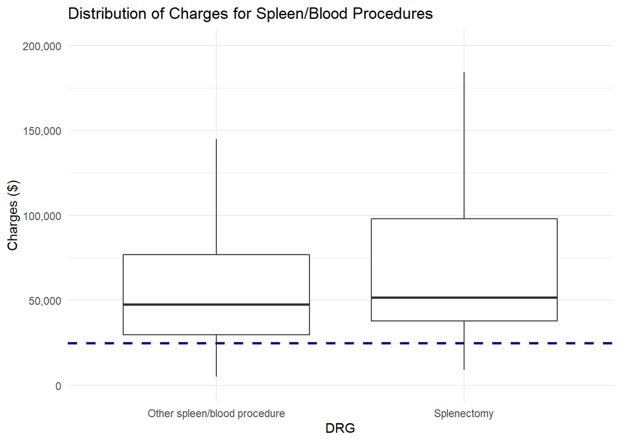

```r
# graph spleen/blood procedures vs. charges
ggplot(filter(hosp, (DRG.Code <=651 & DRG.Code >= 650)),
       aes(x=DRG, y=Charges)) +
  geom_boxplot(outlier.shape=NA) +
  geom_hline(yintercept=median(hosp$Charges), linetype="dashed", size=1, color="navy blue") +
  coord_cartesian(ylim=c(0,200000)) +
  scale_y_continuous(labels=scales::comma) +
  scale_x_discrete(labels=c("Other spleen/blood procedure", "Splenectomy")) +
  ggtitle("Distribution of Charges for Spleen/Blood Procedures") +
  xlab("DRG") +
  ylab("Charges ($)")
```

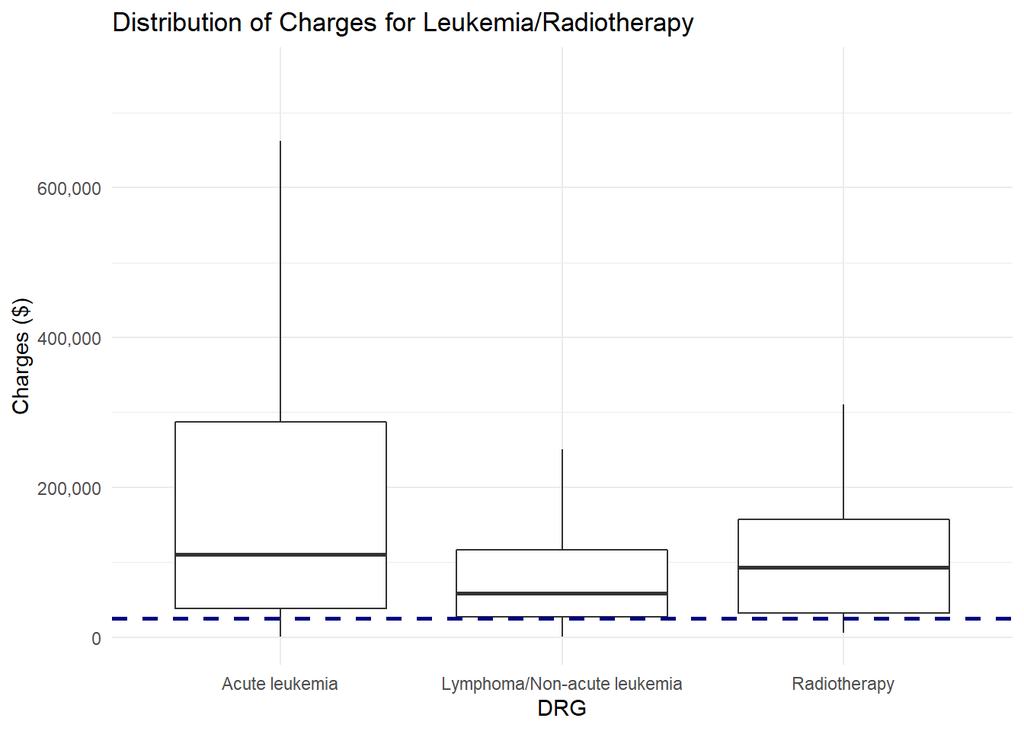

```r
# graph leukemia/radiotherapy vs. charges
ggplot(filter(hosp, (DRG.Code <=692 & DRG.Code >= 690)),
       aes(x=DRG, y=Charges)) +
  geom_boxplot(outlier.shape=NA) +
  geom_hline(yintercept=median(hosp$Charges), linetype="dashed", size=1, color="navy blue") +
  coord_cartesian(ylim=c(0,750000)) +
  scale_y_continuous(labels=scales::comma) +
  scale_x_discrete(labels=c("Acute leukemia","Lymphoma/Non-acute leukemia",
                            "Radiotherapy")) +
  ggtitle("Distribution of Charges for Leukemia/Radiotherapy") +
  xlab("DRG") +
  ylab("Charges ($)")
```

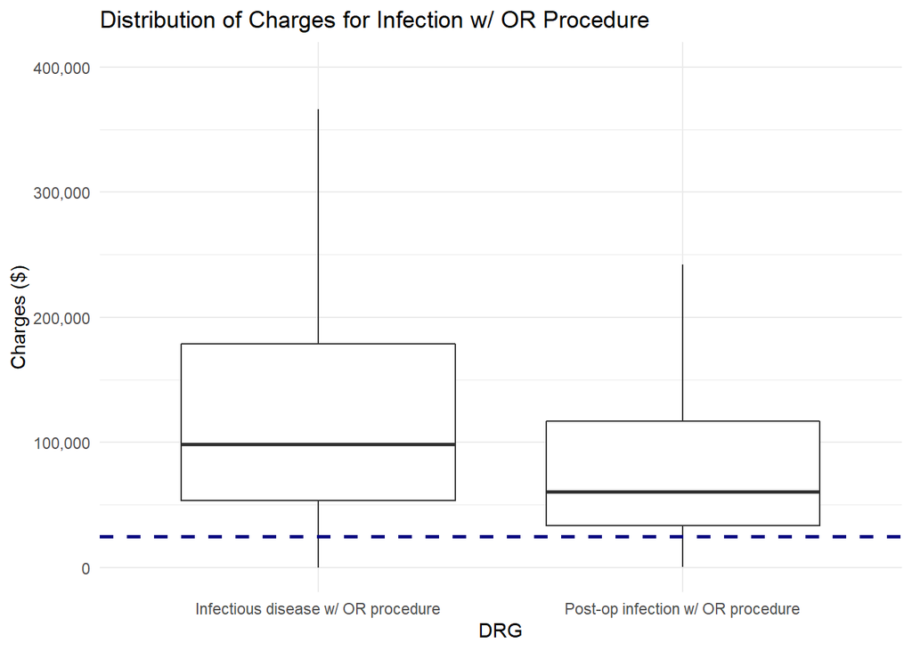

```r
# graph infection w/ OR procedure vs. charges
ggplot(filter(hosp, (DRG.Code <=711 & DRG.Code >= 710)),
       aes(x=DRG, y=Charges)) +
  geom_boxplot(outlier.shape=NA) +
  geom_hline(yintercept=median(hosp$Charges), linetype="dashed", size=1, color="navy blue") +
  coord_cartesian(ylim=c(0,400000)) +
  scale_y_continuous(labels=scales::comma) +
  scale_x_discrete(labels=c("Infectious disease w/ OR procedure",
                            "Post-op infection w/ OR procedure")) +
  ggtitle("Distribution of Charges for Infection w/ OR Procedure") +
  xlab("DRG") +
  ylab("Charges ($)")
```

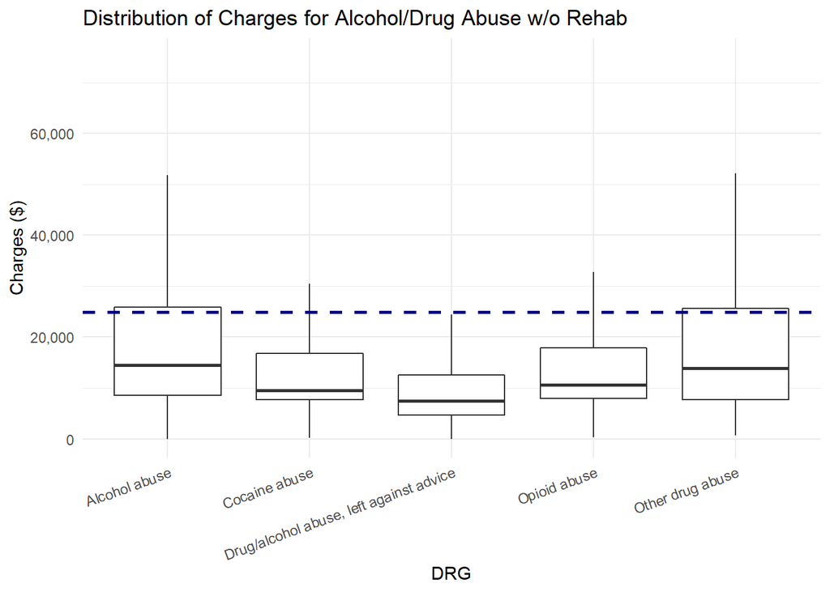

```r
# graph alcohol/drug abuse w/o rehab vs charges
ggplot(filter(hosp, (DRG.Code <=776 & DRG.Code >= 773) | DRG.Code == 770),
       aes(x=DRG, y=Charges)) +
  geom_boxplot(outlier.shape=NA) +
  geom_hline(yintercept=median(hosp$Charges), linetype="dashed", size=1, color="navy blue") +
  coord_cartesian(ylim=c(0,75000)) +
  theme(axis.text.x=element_text(angle=20, hjust=1, vjust=1)) +
  scale_y_continuous(labels=scales::comma) +
  scale_x_discrete(labels=c("Alcohol abuse", "Cocaine abuse",
                            "Drug/alcohol abuse, left against advice",
                            "Opioid abuse", "Other drug abuse")) +
  ggtitle("Distribution of Charges for Alcohol/Drug Abuse w/o Rehab") +
  xlab("DRG") +
  ylab("Charges ($)")
```

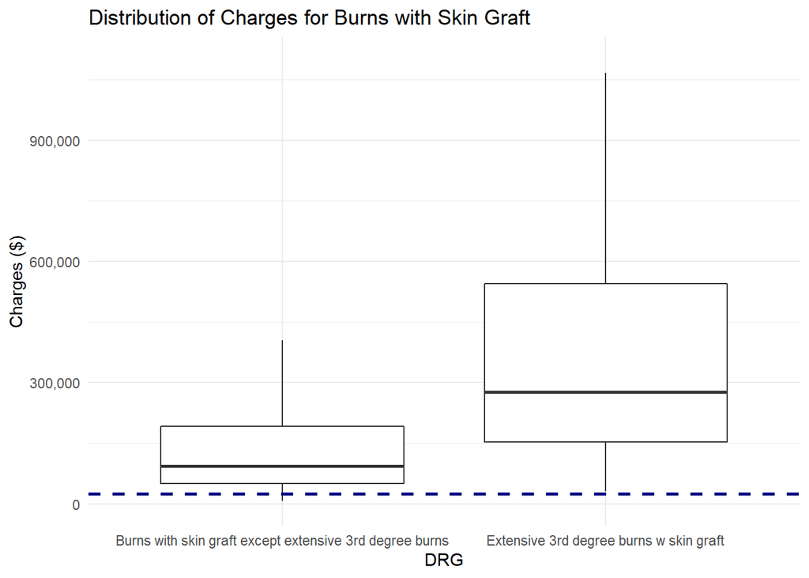

```r
# graph burns w/ skin graft vs. charges
ggplot(filter(hosp, (DRG.Code <=842 & DRG.Code >= 841)),
       aes(x=DRG, y=Charges)) +
  geom_boxplot(outlier.shape=NA) +
  geom_hline(yintercept=median(hosp$Charges), linetype="dashed", size=1, color="navy blue") +
  coord_cartesian(ylim=c(0,1100000)) +
  scale_y_continuous(labels=scales::comma) +
  ggtitle("Distribution of Charges for Burns with Skin Graft") +
  xlab("DRG") +
  ylab("Charges ($)")
```

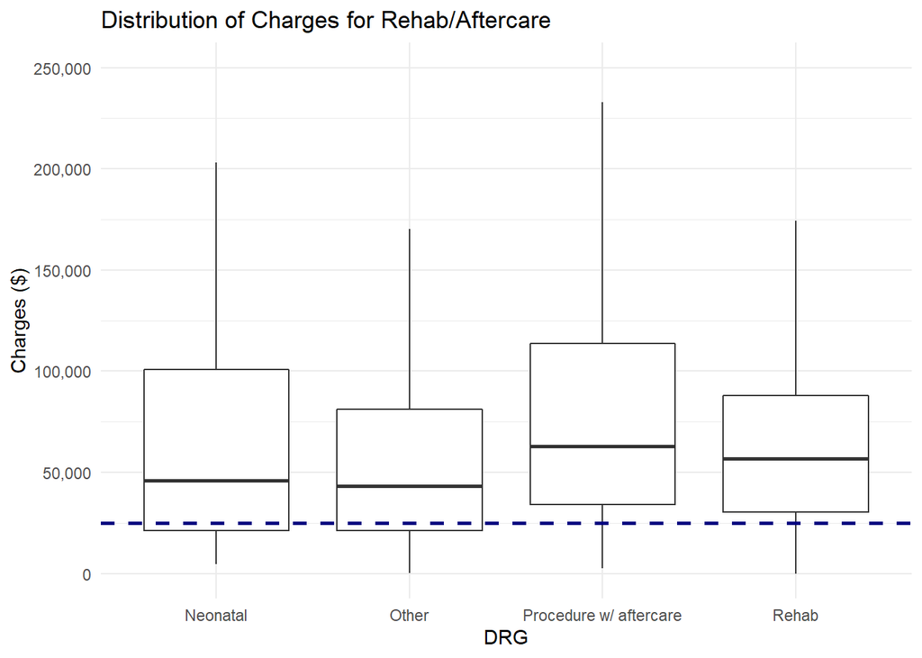

```r
# graph rehab/aftercare vs. charges
ggplot(filter(hosp, (DRG.Code %in% c(850, 860, 862, 863))),
       aes(x=DRG, y=Charges)) +
  geom_boxplot(outlier.shape=NA) +
  geom_hline(yintercept=median(hosp$Charges), linetype="dashed", size=1, color="navy blue") +
  coord_cartesian(ylim=c(0,250000)) +
  scale_x_discrete(labels=c("Neonatal", "Other", "Procedure w/ aftercare", "Rehab")) +
  scale_y_continuous(labels=scales::comma) +
  ggtitle("Distribution of Charges for Rehab/Aftercare") +
  xlab("DRG") +
  ylab("Charges ($)")
```

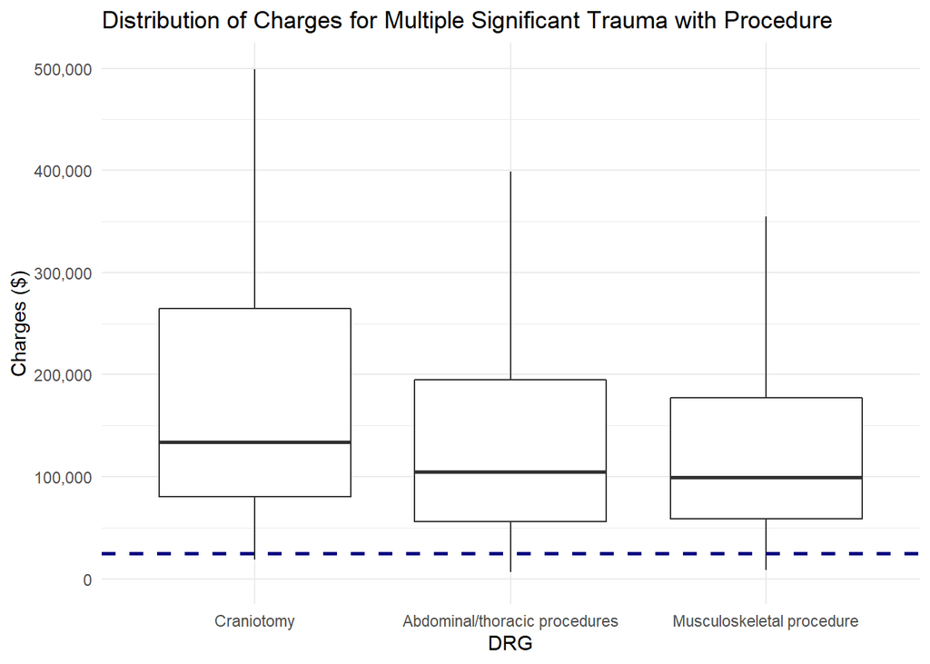

```r
# graph multiple significant trauma with procedure vs. charges
ggplot(filter(hosp, (DRG.Code <=912 & DRG.Code >= 910)),
       aes(x=DRG, y=Charges)) +
  geom_boxplot(outlier.shape=NA) +
  geom_hline(yintercept=median(hosp$Charges), linetype="dashed", size=1, color="navy blue") +
  coord_cartesian(ylim=c(0,500000)) +
  scale_y_continuous(labels=scales::comma) +
  ggtitle("Distribution of Charges for Multiple Significant Trauma with Procedure") +
  scale_x_discrete(labels=c("Craniotomy", "Abdominal/thoracic procedures",
                            "Musculoskeletal procedure")) +
  xlab("DRG") +
  ylab("Charges ($)")
```

## Works Cited

1. Weiss, (https://www.hcup-us.ahrq.gov/reports/statbriefs/sb154.jsp)
2. https://emedicine.medscape.com/article/979717-overview